# Resolución de Consignas — Módulo 2

Juan Marcos Aguirre Simionato

2026-04-15

# Introducción

Este documento resuelve las consignas del Módulo 2 del curso de Técnicas y Herramientas Modernas. Se trabajan los siguientes temas:

- Generación de vectores secuencia y medición de performance
- Serie de Fibonacci
- Ordenamiento burbuja vs. `sort()` nativo de R con gráficos de violín
- Penitencia de Newton (suma 1 a N)
- Agrupamiento K-Means con introducción teórica y medición de performance

# Ejercicio 1 — Variable con últimas 3 cifras del DNI

```r
# Las últimas 3 cifras del DNI son 041
DNI <- 041

# Vector de enteros desde 1 hasta 041
secuencia_dni <- 1:41
secuencia_dni
```

```
##  [1]  1  2  3  4  5  6  7  8  9 10 11 12 13 14 15 16 17 18 19 20 21 22 23 24 25
## [26] 26 27 28 29 30 31 32 33 34 35 36 37 38 39 40 41
```

# Ejercicio 2 — Suma con bucle `for`

```r
total <- 0
valor_final <- length(secuencia_dni)
for (i in 1:valor_final) {
  total <- total + i
}
cat("Suma total:", total, "\n")
```

```
## Suma total: 861
```

# Ejercicio 3 — Mismo ejercicio en Python

En Python (ejecutado como script externo), el equivalente sería:

```python
suma = 0
for i in range(1, 42):   # range(1, 42) genera 1 a 41
    suma += i
print(suma)              # 861
```

# Ejercicio 4 — Tiempo del bucle `for` escalado

```r
inicio <- Sys.time()
total <- 0
valor_final <- 10000000 * length(secuencia_dni)
for (i in 1:valor_final) {
  total <- total + i
}
final <- Sys.time()
cat("Resultado:", total, "\n")
```

```
## Resultado: 8.405e+16
```

```r
cat("Tiempo (for):", as.numeric(final - inicio, units = "secs"), "secs\n")
```

```
## Tiempo (for): 10.31288 secs
```

# Ejercicio 5 — Fórmula de Gauss (eficiente)

```r
inicio <- Sys.time()
valor_final <- 10000000 * length(secuencia_dni)
total <- valor_final * (valor_final + 1) / 2
final <- Sys.time()
cat("Resultado:", total, "\n")
```

```
## Resultado: 8.405e+16
```

```r
cat("Tiempo (Gauss):", as.numeric(final - inicio, units = "secs"), "secs\n")
```

```
## Tiempo (Gauss): 0.00172472 secs
```

# Ejercicio 6 — Uso de `tictoc`

```r
library(tictoc)

tic("sleeping")
A <- 20
print("dormire una siestita...")
```

```
## [1] "dormire una siestita..."
```

```r
Sys.sleep(2)
print("...suena el despertador")
```

```
## [1] "...suena el despertador"
```

```r
toc()
```

```
## sleeping: 2.016 sec elapsed
```

# Ejercicio 7 — `for` vs `seq()` para generar secuencia

```r
# Método FOR
inicio_for <- Sys.time()
A <- numeric(50000)
for (i in 1:50000) {
  A[i] <- i * 2
}
final_for <- Sys.time()
tiempo_for <- as.numeric(final_for - inicio_for, units = "secs")

# Método SEQ
inicio_seq <- Sys.time()
B <- seq(2, 100000, by = 2)
final_seq <- Sys.time()
tiempo_seq <- as.numeric(final_seq - inicio_seq, units = "secs")

cat("Tiempo FOR:", tiempo_for, "secs\n")
```

```
## Tiempo FOR: 0.01442766 secs
```

```r
cat("Tiempo SEQ:", tiempo_seq, "secs\n")
```

```
## Tiempo SEQ: 0.005413055 secs
```

```r
cat("SEQ es", round(tiempo_for / max(tiempo_seq, 1e-6), 1), "veces más rápido\n")
```

```
## SEQ es 2.7 veces más rápido
```

# Ejercicio 8 — Serie de Fibonacci hasta superar 1.000.000

```r
fibonacci <- c(0, 1)
iteraciones <- 2

while (fibonacci[length(fibonacci)] <= 1000000) {
  nuevo <- fibonacci[length(fibonacci)] + fibonacci[length(fibonacci) - 1]
  fibonacci <- c(fibonacci, nuevo)
  iteraciones <- iteraciones + 1
}

cat("Serie de Fibonacci:\n")
```

```
## Serie de Fibonacci:
```

```r
print(fibonacci)
```

```
##  [1]       0       1       1       2       3       5       8      13      21
## [10]      34      55      89     144     233     377     610     987    1597
## [19]    2584    4181    6765   10946   17711   28657   46368   75025  121393
## [28]  196418  317811  514229  832040 1346269
```

```r
cat("\nIteraciones necesarias:", iteraciones, "\n")
```

```
##
## Iteraciones necesarias: 32
```

```r
cat("Último valor generado:", tail(fibonacci, 1), "\n")
```

```
## Último valor generado: 1346269
```

# Ejercicio 9 — Ordenamiento Burbuja vs `sort()` con violín

## Descripción

El algoritmo **Bubble Sort** (burbuja) compara pares adyacentes e intercambia elementos si están en orden incorrecto, repitiendo el proceso hasta ordenar el vector completo. Su complejidad es $O(n^2)$, lo que lo hace ineficiente para vectores grandes.

El comando `sort()` nativo de R implementa un algoritmo híbrido altamente optimizado (basado en *shellsort* o *radix sort*), con complejidad promedio $O(n \log n)$.

## Implementación

```r
library(microbenchmark)

# Muestra de 20.000 números aleatorios
set.seed(123)
x <- sample(1:100000, 20000)

# Función burbuja
burbuja <- function(x) {
  n <- length(x)
  for (j in 1:(n - 1)) {
    for (i in 1:(n - j)) {
      if (x[i] > x[i + 1]) {
        temp   <- x[i]
        x[i]   <- x[i + 1]
        x[i + 1] <- temp
      }
    }
  }
  return(x)
}

# Benchmark (pocas repeticiones para burbuja por su lentitud)
resultado <- microbenchmark(
  burbuja = burbuja(x),
  sort_R  = sort(x),
  times   = 3
)

print(resultado)
```

```
## Unit: milliseconds
##     expr         min           lq         mean       median           uq
##  burbuja 31635.11050 31699.401742 31743.867974 31763.692986 31798.246712
##   sort_R     1.06746     1.104113     1.195648     1.140766     1.259742
##           max neval
##  31832.800438     3
##      1.378717     3
```

## Gráfico de violín

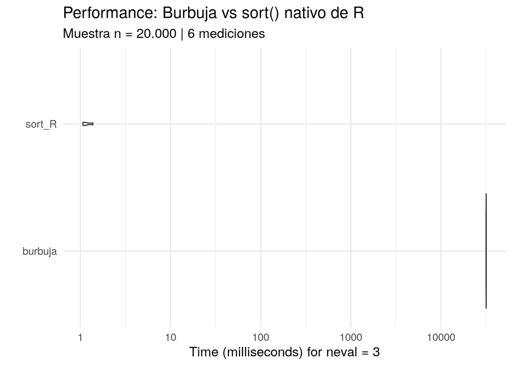

Comparación de tiempos: Burbuja vs sort() nativo

```r
library(ggplot2)
autoplot(resultado) +
  labs(
    title = "Performance: Burbuja vs sort() nativo de R",
    subtitle = paste0("Muestra n = 20.000 | ", nrow(resultado), " mediciones"),
    x = "Método",
    y = "Tiempo (microsegundos)"
  ) +
  theme_minimal(base_size = 13)
```

# Ejercicio 10 — Penitencia de Newton

```r
n <- 10000000

# Método 1: FOR (ineficiente)
inicio1 <- Sys.time()
suma1 <- 0
for (i in 1:n) {
  suma1 <- suma1 + i
}
final1 <- Sys.time()
tiempo1 <- as.numeric(final1 - inicio1, units = "secs")

# Método 2: Fórmula de Gauss
inicio2 <- Sys.time()
suma2 <- n * (n + 1) / 2
final2 <- Sys.time()
tiempo2 <- as.numeric(final2 - inicio2, units = "secs")

cat("=== Penitencia de Newton: suma 1 hasta", n, "===\n")
```

```
## === Penitencia de Newton: suma 1 hasta 1e+07 ===
```

```r
cat("Resultado FOR  :", suma1, "\n")
```

```
## Resultado FOR  : 5e+13
```

```r
cat("Resultado Gauss:", suma2, "\n")
```

```
## Resultado Gauss: 5e+13
```

```r
cat("Tiempo FOR  :", tiempo1, "secs\n")
```

```
## Tiempo FOR  : 0.2556808 secs
```

```r
cat("Tiempo Gauss:", tiempo2, "secs\n")
```

```
## Tiempo Gauss: 0.0009105206 secs
```

```r
cat("Gauss es aproximadamente", round(tiempo1 / max(tiempo2, 1e-9), 0),
    "veces más rápido\n")
```

```
## Gauss es aproximadamente 281 veces más rápido
```

# K-Means — Introducción Teórica y Medición de Performance

## Introducción teórica

El algoritmo **K-Means** es un método de aprendizaje no supervisado que particiona un conjunto de datos en $k$ grupos (clusters) de forma iterativa:

1. Se seleccionan $k$ centroides al azar.
2. Cada observación se asigna al centroide más cercano (distancia euclídea).
3. Se recalcula cada centroide como el promedio de los puntos asignados a él.
4. Se repiten los pasos 2–3 hasta convergencia (sin reasignaciones) o hasta alcanzar el máximo de iteraciones (10 por defecto en R).

El criterio que minimiza es la **suma de cuadrados intra-cluster**:

$$SS(k) = \sum_{i=1}^{n} \sum_{j=1}^{p}
(x_{ij} - \bar{x}_{kj})^2$$

**Consideraciones importantes:**

- Todas las variables deben ser continuas y conviene **estandarizarlas** antes de aplicar k-means (función `scale()`), ya que el algoritmo es sensible a la escala.
- El número de clusters $k$ es un hiperparámetro; se puede estimar con el *método del codo* (`wss`) o con el paquete `NbClust`.
- Los resultados pueden variar entre ejecuciones; se recomienda usar `set.seed()` y el parámetro `nstart` (configuraciones iniciales aleatorias).

```r
library(cluster)
library(factoextra)

# Usamos el dataset iris como sustituto portátil de wine
data(iris)
df <- scale(iris[, 1:4])   # estandarizar variables numéricas
```

## Método del codo — ¿Cuántos clusters?

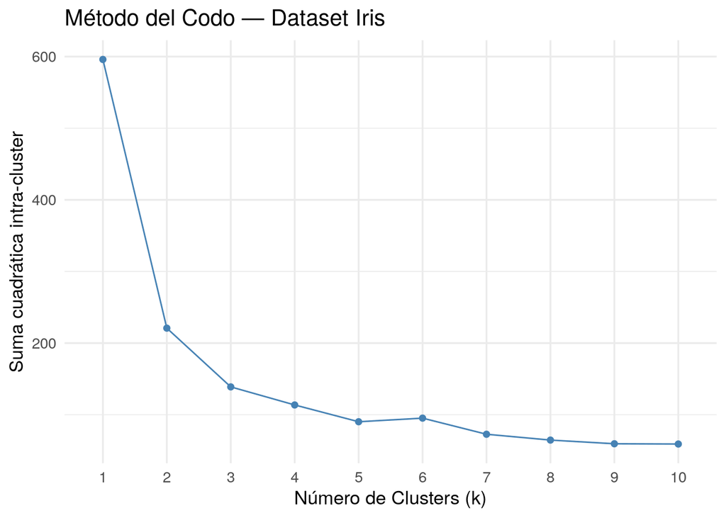

Método del codo: suma cuadrática intra-cluster vs k

```r
fviz_nbclust(df, kmeans, method = "wss") +
  labs(title = "Método del Codo — Dataset Iris",
       x = "Número de Clusters (k)",
       y = "Suma cuadrática intra-cluster") +
  theme_minimal(base_size = 13)
```

## Ajuste del modelo con k = 3

```r
set.seed(42)
fit <- kmeans(df, centers = 3, nstart = 25)

cat("Tamaño de cada cluster:\n")
```

```
## Tamaño de cada cluster:
```

```r
print(fit$size)
```

```
## [1] 50 53 47
```

```r
cat("\nCentroides (escala estandarizada):\n")
```

```
##
## Centroides (escala estandarizada):
```

```r
print(round(fit$centers, 3))
```

```
##   Sepal.Length Sepal.Width Petal.Length Petal.Width
## 1       -1.011       0.850       -1.301      -1.251
## 2       -0.050      -0.880        0.347       0.281
## 3        1.132       0.088        0.993       1.014
```

```r
cat("\nVarianza explicada por los clusters:",
    round(fit$betweenss / fit$totss * 100, 1), "%\n")
```

```
##
## Varianza explicada por los clusters: 76.7 %
```

## Visualización de los clusters

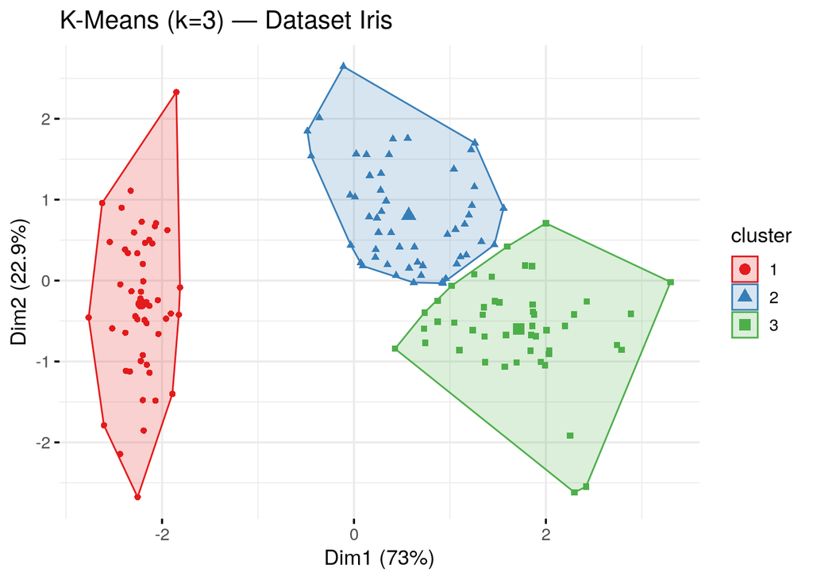

Clusters K-Means sobre las dos primeras componentes principales

```r
fviz_cluster(fit, data = df,
             geom = "point",
             ellipse.type = "convex",
             palette = c("#E41A1C", "#377EB8", "#4DAF4A"),
             ggtheme = theme_minimal(base_size = 13)) +
  labs(title = "K-Means (k=3) — Dataset Iris")
```

## Medición de performance con `microbenchmark`

```r
library(microbenchmark)

set.seed(42)
bench_km <- microbenchmark(
  kmeans_k2  = kmeans(df, centers = 2,  nstart = 25),
  kmeans_k3  = kmeans(df, centers = 3,  nstart = 25),
  kmeans_k5  = kmeans(df, centers = 5,  nstart = 25),
  kmeans_k10 = kmeans(df, centers = 10, nstart = 25),
  times = 50
)

print(bench_km)
```

```
## Unit: milliseconds
##        expr      min       lq     mean   median       uq       max neval
##   kmeans_k2 1.256284 1.304230 1.563536 1.342984 1.382369 10.263593    50
##   kmeans_k3 1.673991 1.763747 1.851778 1.797831 1.855448  2.496563    50
##   kmeans_k5 2.460963 2.584801 2.730955 2.707295 2.829664  3.277105    50
##  kmeans_k10 3.854005 3.998464 4.146647 4.062476 4.252462  4.598165    50
```

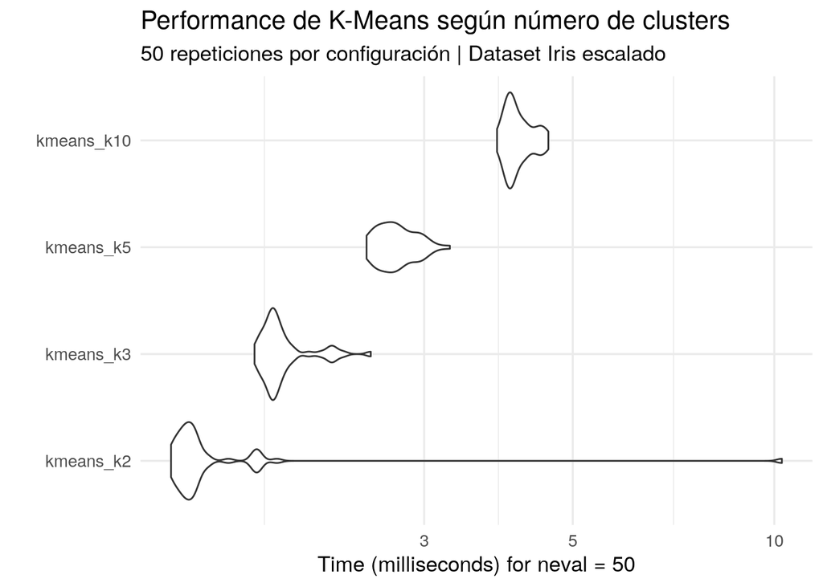

Performance K-Means para distintos valores de k

```r
autoplot(bench_km) +
  labs(
    title = "Performance de K-Means según número de clusters",
    subtitle = "50 repeticiones por configuración | Dataset Iris escalado",
    x = "Configuración",
    y = "Tiempo (microsegundos)"
  ) +
  theme_minimal(base_size = 13)
```